# Factors associated with COVID-19 vaccination

## Purpose

(Taken from https://docs.google.com/document/d/1PZgllPNU8zi2xVPrPDHoBxzQGti7F3C7R9AyqGkKAJU/edit)

Firstly, and obviously, we are not trying to directly estimate the causal effect of any one putative cause on vaccination propensity/timing/uptake. This requires statistical models tailored to each specific causal effect of interest, which we are not doing here. Essentially, we are not providing answers to “what if” questions.

Secondly, it is not feasible to use this model to make predictions about vaccination uptake in the future. The vaccination programme is far too dynamic over time; target populations for vaccination quickly shift from one priority group to the next, vaccine availability will change over time, new policies are introduced in response to emerging evidence about effectiveness, safely, covid risk, inequalities, etc. It is also susceptible to the Prediction Paradox, i.e., predictions influencing policies or behaviors which then invalidates the predictions. This means predictive performance shouldn’t be considered important, and we shouldn’t be providing individualised risk scores.

What is possible, and informative, is to use the model to describe observed differences in vaccine uptake across different patient groups, strictly over the studied period. In particular, this can help to probe apparent inequalities. Not to prove or disprove -- that would require a causal investigation -- but to identify systematic variation in uptake which isn’t sufficiently accounted for by other modelled factors.

## Results

General overview:

- For the 80+ cohort, vaccination uptake decreased with age
- Males were marginally more likely to be vaccinated females
- Black, Asian/Asian British and mixed ethnicities were much less likely to be vaccinated, compared to white
- Decreasing vaccination uptake were seen with increasing levels of deprivation
- Most comorbidities were associated with decreased vaccination uptake, including morbid obesity, diabetes, severve mental illness, learning disability, neurological diseases (including stroke), chronic respiratory disease
- No major rural/urban divide
- Those with a history of covid were less likely to have been vaccinated while those with a hisory of havign the flu jab were more likely to have been vaccinated
- Decreased vaccination uptake in shielding individuals

A full overview of the associations between patient-level factors and covid vaccination are shown in the Figure 1 below. Results also available in Table format after figure.

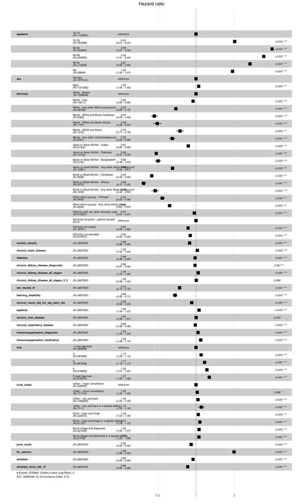

Figure 1: Estimated Hazard Ratios for each potential factor from a stratified Cox model

Table 1. Hazard Ratios (HRs) and 95% confidence intervals (CI) for COVID-19 vaccination

| **Characteristic** | **HR**<sup>1</sup> | **95% CI**<sup>1</sup> | **p-value** |
| --- | --- | --- | --- |
| ageband75-79 | 2.02 | 2.01, 2.03 | <0.001 |
| ageband80-84 | 3.99 | 3.97, 4.00 | <0.001 |
| ageband85-89 | 3.42 | 3.41, 3.44 | <0.001 |
| ageband90-94 | 2.67 | 2.65, 2.69 | <0.001 |
| ageband95+ | 1.94 | 1.92, 1.97 | <0.001 |
| sexMale | 1.05 | 1.05, 1.05 | <0.001 |
| ethnicityWhite - Irish | 0.95 | 0.93, 0.96 | <0.001 |
| ethnicityWhite - Any other White background | 0.69 | 0.69, 0.70 | <0.001 |
| ethnicityMixed - White and Black Caribbean | 0.47 | 0.45, 0.49 | <0.001 |
| ethnicityMixed - White and Black African | 0.49 | 0.46, 0.53 | <0.001 |
| ethnicityMixed - White and Asian | 0.75 | 0.71, 0.79 | <0.001 |
| ethnicityMixed - Any other mixed background | 0.65 | 0.62, 0.68 | <0.001 |
| ethnicityAsian or Asian British - Indian | 0.87 | 0.86, 0.88 | <0.001 |
| ethnicityAsian or Asian British - Pakistani | 0.49 | 0.47, 0.50 | <0.001 |
| ethnicityAsian or Asian British - Bangladeshi | 0.50 | 0.48, 0.53 | <0.001 |
| ethnicityAsian or Asian British - Any other Asian background | 0.65 | 0.64, 0.67 | <0.001 |
| ethnicityBlack or Black British - Caribbean | 0.45 | 0.44, 0.46 | <0.001 |
| ethnicityBlack or Black British - African | 0.39 | 0.37, 0.40 | <0.001 |
| ethnicityBlack or Black British - Any other Black background | 0.48 | 0.45, 0.50 | <0.001 |
| ethnicityOther ethnic groups - Chinese | 0.54 | 0.52, 0.56 | <0.001 |
| ethnicityOther ethnic groups - Any other ethnic group | 0.62 | 0.60, 0.63 | <0.001 |
| ethnicityPatients with any other ethnicity code | 0.97 | 0.97, 0.97 | <0.001 |
| ethnicityEthnicity not stated | 0.87 | 0.85, 0.88 | <0.001 |
| ethnicityEthnicity not recorded | 0.90 | 0.90, 0.90 | <0.001 |
| morbid_obesity | 0.89 | 0.88, 0.90 | <0.001 |
| chronic_heart_disease | 1.02 | 1.02, 1.03 | <0.001 |
| diabetes | 0.98 | 0.98, 0.99 | <0.001 |
| chronic_kidney_disease_diagnostic | 0.98 | 0.97, 0.99 | 0.001 |
| chronic_kidney_disease_all_stages | 1.04 | 1.03, 1.05 | <0.001 |
| chronic_kidney_disease_all_stages_3_5 | 1.00 | 0.99, 1.02 | 0.4 |
| sev_mental_ill | 0.74 | 0.73, 0.75 | <0.001 |
| learning_disability | 0.68 | 0.66, 0.71 | <0.001 |
| chronic_neuro_dis_inc_sig_learn_dis | 0.92 | 0.92, 0.93 | <0.001 |
| asplenia | 1.06 | 1.04, 1.07 | <0.001 |
| chronic_liver_disease | 1.00 | 0.99, 1.01 | 0.5 |
| chronis_respiratory_disease | 0.99 | 0.98, 0.99 | <0.001 |
| immunosuppression_diagnosis | 1.04 | 1.03, 1.04 | <0.001 |
| immunosuppression_medication | 1.09 | 1.08, 1.10 | <0.001 |
| imd2 | 1.10 | 1.09, 1.10 | <0.001 |
| imd3 | 1.17 | 1.16, 1.17 | <0.001 |
| imd4 | 1.22 | 1.21, 1.22 | <0.001 |
| imd5 least deprived | 1.27 | 1.26, 1.28 | <0.001 |
| rural_urbanUrban - minor conurbation | 1.02 | 1.00, 1.04 | 0.038 |
| rural_urbanUrban - city and town | 1.04 | 1.02, 1.05 | <0.001 |
| rural_urbanUrban - city and town in a sparse setting | 1.10 | 1.05, 1.16 | <0.001 |
| rural_urbanRural - town and fringe | 1.04 | 1.03, 1.06 | <0.001 |
| rural_urbanRural - town and fringe in a sparse setting | 1.07 | 1.05, 1.10 | <0.001 |
| rural_urbanRural village and dispersed | 1.06 | 1.04, 1.07 | <0.001 |
| rural_urbanRural village and dispersed in a sparse setting | 1.05 | 1.03, 1.08 | <0.001 |
| prior_covid | 0.92 | 0.90, 0.93 | <0.001 |
| flu_vaccine | 1.99 | 1.99, 2.00 | <0.001 |
| shielded | 0.95 | 0.94, 0.95 | <0.001 |
| shielded_since_feb_15 | 0.86 | 0.85, 0.86 | <0.001 |

<sup>*1*</sup> HR = Hazard Ratio, CI = Confidence Interval